# Ford GoBike Data Set

## Introduction

> This data set includes information about over 183,000 individual rides made in a bike-sharing system covering the greater San Francisco Bay area. The dataset includes features such as the customer type, gender, birth year and ride duration amongst other variables.

## Preliminary Wrangling

```python
# import all packages and set plots to be embedded inline
import numpy as np
import pandas as pd
import matplotlib.pyplot as plt
import seaborn as sb
sb.set_style('darkgrid')

%matplotlib inline
```

> Load in your dataset and describe its properties through the questions below. Try and motivate your exploration goals through this section.

```python
# loads the dataset into the notebook and views the first 5 rows to get a feel of the dataset
bike_rides = pd.read_csv('201902-fordgobike-tripdata.csv')
bike_rides.sample(10)
```

|  | duration_sec | start_time | end_time | start_station_id | start_station_name | start_station_latitude | start_station_longitude | end_station_id | end_station_name | end_station_latitude | end_station_longitude | bike_id | user_type | member_birth_year | member_gender | bike_share_for_all_trip |
| --- | --- | --- | --- | --- | --- | --- | --- | --- | --- | --- | --- | --- | --- | --- | --- | --- |
| 130453 | 106 | 2019-02-09 17:27:44.4990 | 2019-02-09 17:29:31.1560 | 336.0 | Potrero Ave and Mariposa St | 37.763281 | -122.407377 | 89.0 | Division St at Potrero Ave | 37.769218 | -122.407646 | 2614 | Subscriber | 1994.0 | Male | No |
| 158158 | 438 | 2019-02-05 19:39:41.3540 | 2019-02-05 19:46:59.4240 | 97.0 | 14th St at Mission St | 37.768265 | -122.420110 | 95.0 | Sanchez St at 15th St | 37.766219 | -122.431060 | 5569 | Subscriber | 1983.0 | Male | No |
| 21660 | 397 | 2019-02-26 09:02:39.4480 | 2019-02-26 09:09:16.7130 | 62.0 | Victoria Manalo Draves Park | 37.777791 | -122.406432 | 3.0 | Powell St BART Station (Market St at 4th St) | 37.786375 | -122.404904 | 5284 | Subscriber | 1994.0 | Male | No |
| 147914 | 531 | 2019-02-07 06:47:53.7370 | 2019-02-07 06:56:45.0550 | 84.0 | Duboce Park | 37.769201 | -122.433812 | 89.0 | Division St at Potrero Ave | 37.769218 | -122.407646 | 5019 | Subscriber | 1990.0 | Male | No |
| 20855 | 779 | 2019-02-26 10:13:14.2320 | 2019-02-26 10:26:13.5970 | 126.0 | Esprit Park | 37.761634 | -122.390648 | 16.0 | Steuart St at Market St | 37.794130 | -122.394430 | 4625 | Customer | 1989.0 | Female | No |
| 33897 | 134 | 2019-02-24 10:20:01.7630 | 2019-02-24 10:22:16.7320 | 50.0 | 2nd St at Townsend St | 37.780526 | -122.390288 | 67.0 | San Francisco Caltrain Station 2 (Townsend St... | 37.776639 | -122.395526 | 4719 | Subscriber | 1990.0 | Male | No |
| 168686 | 347 | 2019-02-04 14:00:03.9190 | 2019-02-04 14:05:51.7180 | 33.0 | Golden Gate Ave at Hyde St | 37.781650 | -122.415408 | 55.0 | Webster St at Grove St | 37.777053 | -122.429558 | 5573 | Subscriber | 1986.0 | Female | No |
| 44066 | 533 | 2019-02-22 15:34:39.3300 | 2019-02-22 15:43:32.8840 | 204.0 | 55th St at Telegraph Ave | 37.840186 | -122.261823 | 248.0 | Telegraph Ave at Ashby Ave | 37.855956 | -122.259795 | 5434 | Subscriber | 1990.0 | Female | No |
| 50335 | 306 | 2019-02-21 19:23:42.7180 | 2019-02-21 19:28:48.9070 | 252.0 | Channing Way at Shattuck Ave | 37.865847 | -122.267443 | 245.0 | Downtown Berkeley BART | 37.870139 | -122.268422 | 4790 | Subscriber | 1990.0 | Male | No |
| 6507 | 310 | 2019-02-28 10:11:12.6030 | 2019-02-28 10:16:23.2600 | 67.0 | San Francisco Caltrain Station 2 (Townsend St... | 37.776639 | -122.395526 | 79.0 | 7th St at Brannan St | 37.773492 | -122.403673 | 1900 | Subscriber | 1985.0 | Male | No |

```python
print(bike_rides.shape) #To view the column data types, column names and shape of the loaded dataset
bike_rides.info()
```

```
(183412, 16)
<class 'pandas.core.frame.DataFrame'>
RangeIndex: 183412 entries, 0 to 183411
Data columns (total 16 columns):
duration_sec               183412 non-null int64
start_time                 183412 non-null object
end_time                   183412 non-null object
start_station_id           183215 non-null float64
start_station_name         183215 non-null object
start_station_latitude     183412 non-null float64
start_station_longitude    183412 non-null float64
end_station_id             183215 non-null float64
end_station_name           183215 non-null object
end_station_latitude       183412 non-null float64
end_station_longitude      183412 non-null float64
bike_id                    183412 non-null int64
user_type                  183412 non-null object
member_birth_year          175147 non-null float64
member_gender              175147 non-null object
bike_share_for_all_trip    183412 non-null object
dtypes: float64(7), int64(2), object(7)
memory usage: 22.4+ MB
```

```python
#checking how many null values are in each column
bike_rides.isnull().sum()
```

```
duration_sec                  0
start_time                    0
end_time                      0
start_station_id            197
start_station_name          197
start_station_latitude        0
start_station_longitude       0
end_station_id              197
end_station_name            197
end_station_latitude          0
end_station_longitude         0
bike_id                       0
user_type                     0
member_birth_year          8265
member_gender              8265
bike_share_for_all_trip       0
dtype: int64
```

# Data Cleaning

## Issue 1 :

### There are several rows with null values.

### Define: Drop all null values in the data set.

### Code:

```python
bike_rides.dropna(inplace = True)

#TEST:

bike_rides.isnull().sum()
```

```
duration_sec               0
start_time                 0
end_time                   0
start_station_id           0
start_station_name         0
start_station_latitude     0
start_station_longitude    0
end_station_id             0
end_station_name           0
end_station_latitude       0
end_station_longitude      0
bike_id                    0
user_type                  0
member_birth_year          0
member_gender              0
bike_share_for_all_trip    0
dtype: int64
```

# Issue 2:

## There are some columns in the wrong data type - start_time, end_time station_id and bike_id

### Define:

Convert start_time and end_time to datetime, staion_ids and bike_id to type string.

### Code:

```python
#Converts start_time and end_time to datetime
bike_rides['start_time'] = pd.to_datetime(bike_rides['start_time'])
bike_rides['end_time'] = pd.to_datetime(bike_rides['end_time'])

#converts bike_id, start_station_id and end_station_id to string
bike_rides['bike_id'] = bike_rides.bike_id.astype('str')
bike_rides['start_station_id'] = bike_rides.start_station_id.astype('str')
bike_rides['end_station_id'] = bike_rides.end_station_id.astype('str')

#TEST

bike_rides.dtypes
```

```
duration_sec                        int64
start_time                 datetime64[ns]
end_time                   datetime64[ns]
start_station_id                   object
start_station_name                 object
start_station_latitude            float64
start_station_longitude           float64
end_station_id                     object
end_station_name                   object
end_station_latitude              float64
end_station_longitude             float64
bike_id                            object
user_type                          object
member_birth_year                 float64
member_gender                      object
bike_share_for_all_trip            object
dtype: object
```

# Feature Engineering

I would like to add columns for the day, month and hour rides occurred as this will help me answer some of my research questions

```python
import datetime as dt
#Add new columns to the data, containing extracted day, month and hour from the start_time column
bike_rides['start_day'] = bike_rides['start_time'].dt.day_name()
bike_rides['start_month'] = bike_rides['start_time'].dt.month_name()
bike_rides['start_hr'] = bike_rides['start_time'].dt.hour
bike_rides['start_hr'] = bike_rides.start_hr.astype(str)



bike_rides['end_day'] = bike_rides['end_time'].dt.day_name()
bike_rides['end_month'] = bike_rides['end_time'].dt.month_name()
bike_rides['end_hr'] = bike_rides['end_time'].dt.hour
bike_rides['end_hr'] = bike_rides.end_hr.astype(str)
```

```python
#Change  start day, month and hour to categorical data types

# convert day, and hour into ordered categorical types
var_dict = {'start_day': ['Monday','Tuesday','Wednesday','Thursday','Friday', 'Saturday', 'Sunday'],
            'end_day': ['Monday','Tuesday','Wednesday','Thursday','Friday', 'Saturday', 'Sunday'],
            'start_month': ['January', 'February',
            'March','April', 'May','June', 'July', 'August', 'September', 'October', 'November', 'December'],
            'end_month': ['January', 'February',
            'March','April', 'May','June', 'July', 'August', 'September', 'October', 'November', 'December'],
            'start_hr': [str(i) for i in range(0,24)],
            'end_hr': [str(i) for i in range(0,24)]}

for v in var_dict:
    ordered_var = pd.api.types.CategoricalDtype(ordered = True,
                                                categories = var_dict[v])
    bike_rides[v] = bike_rides[v].astype(ordered_var)
```

```python
print(bike_rides.dtypes)
print(20*'#')
print(bike_rides.info())
bike_rides.sample(5)
```

```
duration_sec                        int64
start_time                 datetime64[ns]
end_time                   datetime64[ns]
start_station_id                   object
start_station_name                 object
start_station_latitude            float64
start_station_longitude           float64
end_station_id                     object
end_station_name                   object
end_station_latitude              float64
end_station_longitude             float64
bike_id                            object
user_type                          object
member_birth_year                 float64
member_gender                      object
bike_share_for_all_trip            object
start_day                        category
start_month                      category
start_hr                         category
end_day                          category
end_month                        category
end_hr                           category
dtype: object
####################
<class 'pandas.core.frame.DataFrame'>
Int64Index: 174952 entries, 0 to 183411
Data columns (total 22 columns):
duration_sec               174952 non-null int64
start_time                 174952 non-null datetime64[ns]
end_time                   174952 non-null datetime64[ns]
start_station_id           174952 non-null object
start_station_name         174952 non-null object
start_station_latitude     174952 non-null float64
start_station_longitude    174952 non-null float64
end_station_id             174952 non-null object
end_station_name           174952 non-null object
end_station_latitude       174952 non-null float64
end_station_longitude      174952 non-null float64
bike_id                    174952 non-null object
user_type                  174952 non-null object
member_birth_year          174952 non-null float64
member_gender              174952 non-null object
bike_share_for_all_trip    174952 non-null object
start_day                  174952 non-null category
start_month                174952 non-null category
start_hr                   174952 non-null category
end_day                    174952 non-null category
end_month                  174952 non-null category
end_hr                     174952 non-null category
dtypes: category(6), datetime64[ns](2), float64(5), int64(1), object(8)
memory usage: 23.7+ MB
None
```

|  | duration_sec | start_time | end_time | start_station_id | start_station_name | start_station_latitude | start_station_longitude | end_station_id | end_station_name | end_station_latitude | ... | user_type | member_birth_year | member_gender | bike_share_for_all_trip | start_day | start_month | start_hr | end_day | end_month | end_hr |
| --- | --- | --- | --- | --- | --- | --- | --- | --- | --- | --- | --- | --- | --- | --- | --- | --- | --- | --- | --- | --- | --- |
| 18262 | 1661 | 2019-02-26 18:37:21.131 | 2019-02-26 19:05:02.303 | 25.0 | Howard St at 2nd St | 37.787522 | -122.397405 | 20.0 | Mechanics Monument Plaza (Market St at Bush St) | 37.791300 | ... | Subscriber | 1993.0 | Male | No | Tuesday | February | 18 | Tuesday | February | 19 |
| 96932 | 655 | 2019-02-15 09:28:53.972 | 2019-02-15 09:39:49.452 | 174.0 | Shattuck Ave at 51st St | 37.836801 | -122.264004 | 266.0 | Parker St at Fulton St | 37.862464 | ... | Subscriber | 1993.0 | Male | No | Friday | February | 9 | Friday | February | 9 |
| 129195 | 418 | 2019-02-10 11:14:21.594 | 2019-02-10 11:21:20.033 | 270.0 | Ninth St at Heinz Ave | 37.853489 | -122.289415 | 263.0 | Channing Way at San Pablo Ave | 37.862827 | ... | Subscriber | 1995.0 | Male | No | Sunday | February | 11 | Sunday | February | 11 |
| 149471 | 796 | 2019-02-06 19:09:56.918 | 2019-02-06 19:23:13.345 | 22.0 | Howard St at Beale St | 37.789756 | -122.394643 | 91.0 | Berry St at King St | 37.771762 | ... | Subscriber | 1997.0 | Female | No | Wednesday | February | 19 | Wednesday | February | 19 |
| 42322 | 214 | 2019-02-22 17:43:54.774 | 2019-02-22 17:47:29.023 | 266.0 | Parker St at Fulton St | 37.862464 | -122.264791 | 274.0 | Oregon St at Adeline St | 37.857567 | ... | Subscriber | 1998.0 | Female | No | Friday | February | 17 | Friday | February | 17 |

5 rows × 22 columns

```python
bike_rides.describe()
```

|  | duration_sec | start_station_latitude | start_station_longitude | end_station_latitude | end_station_longitude | member_birth_year |
| --- | --- | --- | --- | --- | --- | --- |
| count | 174952.000000 | 174952.000000 | 174952.000000 | 174952.000000 | 174952.000000 | 174952.000000 |
| mean | 704.002744 | 37.771220 | -122.351760 | 37.771414 | -122.351335 | 1984.803135 |
| std | 1642.204905 | 0.100391 | 0.117732 | 0.100295 | 0.117294 | 10.118731 |
| min | 61.000000 | 37.317298 | -122.453704 | 37.317298 | -122.453704 | 1878.000000 |
| 25% | 323.000000 | 37.770407 | -122.411901 | 37.770407 | -122.411647 | 1980.000000 |
| 50% | 510.000000 | 37.780760 | -122.398279 | 37.781010 | -122.397437 | 1987.000000 |
| 75% | 789.000000 | 37.797320 | -122.283093 | 37.797673 | -122.286533 | 1992.000000 |
| max | 84548.000000 | 37.880222 | -121.874119 | 37.880222 | -121.874119 | 2001.000000 |

### What is the structure of your dataset?

> The data set originally contained 16 variables or features and 183,412 observations. However, after some preliminary wrangling and feature engineering, i have 174,952 observations and 22 variables.

### What is/are the main feature(s) of interest in your dataset?

> I think ride duration(secs) is the stand out variable in this dataset. I am interested in the exploring how variables like gender, customer type, date, time, age and station affect how long a ride lasts.

### What features in the dataset do you think will help support your investigation into your feature(s) of interest?

> Duration(secs), gender, datetime, customer type, user type will all be explored to help answer some of my research questions.

# Univariate Exploration

## How is the duration variable distributed? Is it unimodal or bimodal? What are the most common points in the distribution?

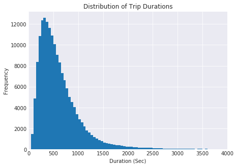

```python
# code below builds a standard histogram to view the distribution
bin_size = 50
bins = np.arange(50, bike_rides['duration_sec'].max()+bin_size, bin_size)

plt.figure(figsize=[7, 5])
plt.hist(data = bike_rides, x = 'duration_sec', bins=bins)
plt.xlabel('Duration (Sec)')
plt.ylabel('Frequency')
plt.title('Distribution of Trip Durations')
#The data set has some few extreme outliers. The below code helps us view the most dense portion of the data
plt.xlim([0, 4000]);
```

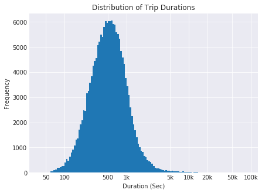

```python
## I am replotting the distribution using a log scale as the data
## has a huge skew to the right which may blur some useful information


log_binsize = 0.025
bins = 10 ** np.arange(1.6, np.log10(bike_rides['duration_sec'].max())+log_binsize, log_binsize)

plt.figure(figsize=[7, 5])
plt.hist(data = bike_rides, x = 'duration_sec', bins=bins)
plt.xscale('log')
plt.xticks([50, 1e2, 5e2, 1e3, 5e3, 1e4, 2e4, 5e4, 1e5], [50, '100', '500', '1k', '5k', '10k', '20k', '50k', '100k'])
plt.title('Distribution of Trip Durations')
plt.xlabel('Duration (Sec)')
plt.ylabel('Frequency');
```

### How are the customers/subscribers birth years distributed?

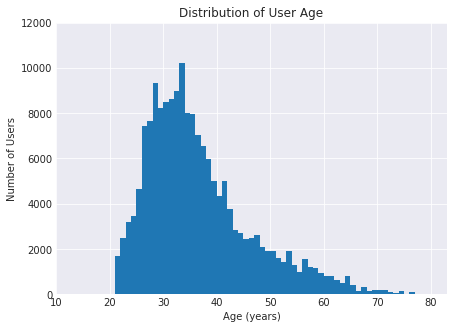

```python
# The code below plots age distribution derived from member's birth year.
year_bin_size = 1
year_bins = np.arange(0, bike_rides['member_birth_year'].astype(float).max()+year_bin_size, year_bin_size)

plt.figure(figsize=[7, 5])
plt.hist(data = bike_rides, x = 'member_birth_year', bins = year_bins)
plt.axis([1939, 2009, 0, 12000]) #Sets limits for y and x axis in a single call
plt.xticks([1942, 1952, 1962, 1972, 1982, 1992, 2002, 2012], [(2022-1942), (2022-1952), (2022-1962), (2022-1972), (2022-1982), (2022-1992), (2022-2002), (2022-2012)])
plt.gca().invert_xaxis()
plt.title('Distribution of User Age')
plt.xlabel('Age (years)')
plt.ylabel('Number of Users');
```

The age distribution is skewed to the right with some members above 40. However the most common age appears to be around 35 with most of the customers being between 30 and 40 years of age

## Which day had the most rides?

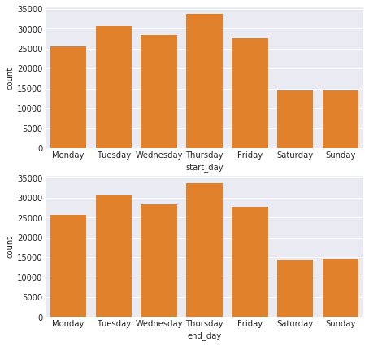

```python
# code below plots the frequency of rides per days

fig, ax = plt.subplots(2, figsize = [7,7])

plot_color = sb.color_palette()[1]
sb.countplot(data = bike_rides, x = 'start_day', color = plot_color,  ax = ax[0])
sb.countplot(data = bike_rides, x = 'end_day', color = plot_color,  ax = ax[1]);
```

It appears the most rides occurred on Thursdays for the period. It will be interesting to see if this is as a result of some factors specific to Thursdays or simply a coincidence. However, it is clear that the least rides occur during the weekend.

```python
# plotting types of users.
def member_type_plot():
    plt.figure(figsize=[8,5])
    plt.bar(x = bike_rides.user_type.value_counts().keys(), height = bike_rides.user_type.value_counts() )
    plt.xlabel('User Type')
    plt.ylabel('Number of Users');
```

```python
# code below plots genders on a bar.
def gender_plot():
    plt.figure(figsize=[8,7])
    plt.bar(x = bike_rides.member_gender.value_counts().keys(), height = bike_rides.member_gender.value_counts() )
    plt.xlabel('Gender')
    plt.ylabel('Number of Users')
    plt.title('Gender of Members');
```

What are the peak periods for ride sharing within a span of 24 hours?

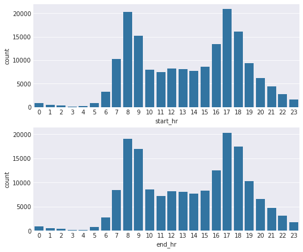

```python
# plots the ride frequency per hours

fig, ax = plt.subplots(2, figsize = [8,7])

default_color = sb.color_palette()[0]
sb.countplot(data = bike_rides, x = 'start_hr', color = default_color,  ax = ax[0])
sb.countplot(data = bike_rides, x = 'end_hr', color = default_color, ax = ax[1]);
```

The most common start and end hours the 8th, 17th and 18th hour suggesting that there are usually more rides during rush hours - When people are leaving for work, and when they are getting back home

## Bivariate Exploration

I would like to see the relationship between trip duration and age. Is there a correlation between the age of members and the amount of time they spend on trips?

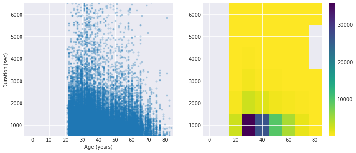

```python
plt.figure(figsize=[12,5])

plt.subplot(1, 2, 1)
plt.scatter((2022 - bike_rides['member_birth_year']), bike_rides['duration_sec'], alpha = 0.25, marker = '.' )
plt.axis([-5, 85, 500, 6500])
plt.xlabel('Age (years)')
plt.ylabel('Duration (sec)')

plt.subplot(1, 2, 2)
binsy = np.arange(500, 6500+1, 1000)
binsx = np.arange(-5, 85+1, 10)
plt.hist2d((2022 - bike_rides['member_birth_year']), bike_rides['duration_sec'],
           bins = [binsx, binsy], cmin = 0.5, cmap = 'viridis_r')
plt.colorbar(ticks=[10000, 20000, 30000, 40000]);
```

From the above, it appears younger members record the highest trip durations. The heatmap shows the biggest area of activity is between 20 and 40 year old recording trip durations below 1,500 seconds.

## How are Trip Durations distributed for each member type? Customers and Subscribers

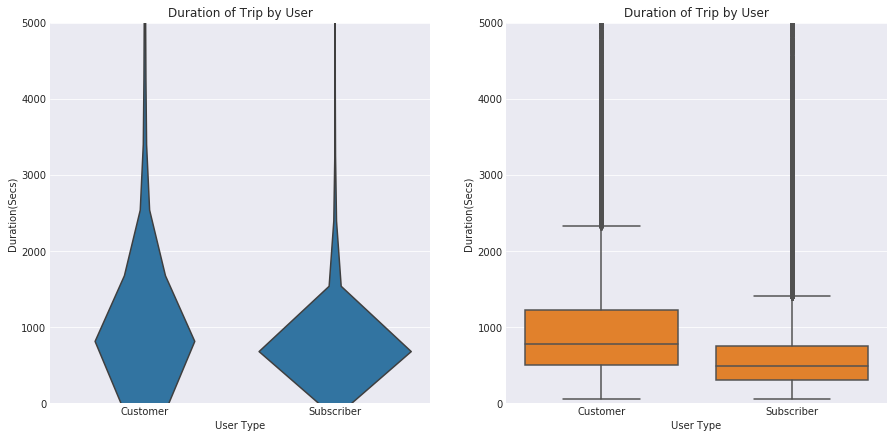

```python
plt.figure(figsize=[15,7])
plt.subplot(1,2,1)
sb.violinplot(data = bike_rides, x = 'user_type', y = 'duration_sec', inner = None, color = sb.color_palette()[0])
plt.xlabel('User Type')
plt.ylabel('Duration(Secs)')
plt.ylim([0, 5000]) #Trip Duration is very widespread, this will help us zoom in at the most active part of the data
plt.title('Duration of Trip by User');

#Let us also view this on a box plot to view summary statistics better

plt.subplot(1,2,2)
sb.boxplot(data = bike_rides, x = 'user_type', y = 'duration_sec',color = sb.color_palette()[1])
plt.xlabel('User Type')
plt.ylabel('Duration(Secs)')
plt.ylim([0, 5000]) #Trip Duration is very widespread, this will help us zoom in at the most active part of the data
plt.title('Duration of Trip by User');
```

There are lot of rides that last just around 1000 seconds, however subscribers seem to to have a lot of rides that end just below 1000 seconds. As expected, there is a long tail in the distribution after 1500 seconds suggesting both customers and subscribers rarely engage in long rides.

From the boxplots, customers engage in longer trips which is good for the business. The business should aim to convert its subscribers as quickly as possible

## Is there a relationship betweeb trip duration and days of the week? Are there more trips on average on weekends than weekdays?

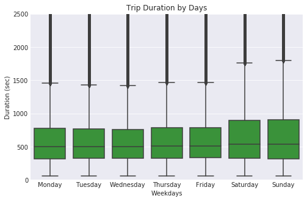

```python
plt.figure(figsize = [8, 5])
base_color = sb.color_palette()[2]
sb.boxplot(data = bike_rides, x = 'start_day', y = 'duration_sec', color = base_color)
plt.ylim([0, 2500]) #Necessary to zoom in on the important aspects of the data
plt.xlabel('Weekdays')
plt.ylabel('Duration (sec)')
plt.title('Trip Duration by Days');
```

# MultiVariate Exploration

What are the relationships between Trip Duration, Gender and Weekdays? Do males spend more time on trips on weekends than females?

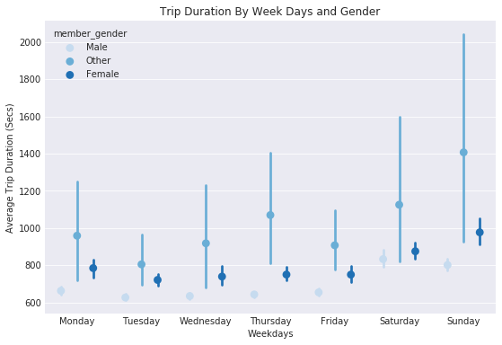

```python
fig = plt.figure(figsize = [9,6])
order = ['Monday','Tuesday','Wednesday','Thursday','Friday', 'Saturday', 'Sunday']
ax = sb.pointplot(data = bike_rides, x ='start_day', y = 'duration_sec', hue = 'member_gender',
           palette = 'Blues', linestyles = '', dodge = 0.5, order = order)
plt.title('Trip Duration By Week Days and Gender')
plt.ylabel('Average Trip Duration (Secs)')
plt.xlabel('Weekdays')
ax.set_yticklabels([],minor = True);
```

Females generally have higher trip durations than males and this does not change on weekends. Surprisingly, the other gender engage in longer trips than both males and females.

#### What is the relationship between trip duration, start hour and gender? Do trips by males have a different peak period than females? What time of the day records the highest trip durations.

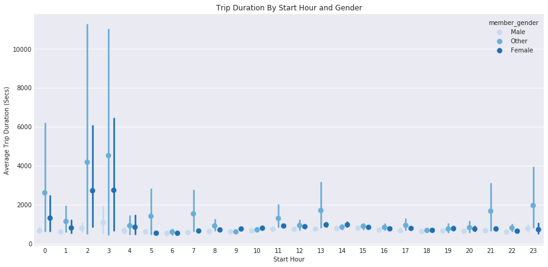

```python
ig = plt.figure(figsize = [15,7])
ax = sb.pointplot(data = bike_rides, x ='start_hr', y = 'duration_sec', hue = 'member_gender',
           palette = 'Blues', linestyles = '', dodge = 0.5)
plt.title('Trip Duration By Start Hour and Gender')
plt.ylabel('Average Trip Duration (Secs)')
plt.xlabel('Start Hour')
ax.set_yticklabels([],minor = True);
```

Trips that start around 12am, 2am and 3am are clearly longer than the others. Females spend longer periods during rides except at 11pm,5am and 6am

### Do trips with bike share for all trips set to test last longer than the others and is this affected by the gender of the rider?

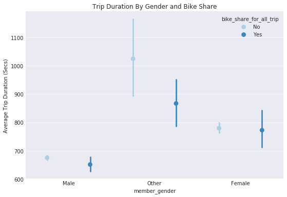

```python
fig = plt.figure(figsize = [9,6])
ax = sb.pointplot(data = bike_rides, x ='member_gender', y = 'duration_sec', hue = 'bike_share_for_all_trip',
           palette = 'Blues', linestyles = '', dodge = 0.5)
plt.title('Trip Duration By Gender and Bike Share')
plt.ylabel('Average Trip Duration (Secs)')
ax.set_yticklabels([],minor = True);
```

Trips with bike share set to No last longer and male trips dont last as long as female trips or trips by the other gender.

> There were less trips on weekends than weekdays consistently during exploration however they tended to last longer than trips on weekdays.

> I was really surprised to see that female trips lasted longer on average than male trips. Why this is happening should be a further reason for investigation. Additionally those who do not disclose their gender engage in higher duration trips.